# Mod-B Exam Simulation

2025-04-18

### **The `UScrime` dataset**

Criminologists are interested in the effect of punishment regimes on crime rates. This has been studied using aggregate data on 47 states of the USA for 1960. The data set contains the following columns:

- `M` percentage of males aged 14–24 in total state population
- `So` indicator variable for a southern state
- `Ed` mean years of schooling of the population aged 25 years or over
- `Po1` per capita expenditure on police protection in 1960
- `Po2` per capita expenditure on police protection in 1959
- `LF` labour force participation rate of civilian urban males in the age-group 14-24
- `M.F` number of males per 100 females
- `Pop` state population in 1960 in hundred thousands
- `NW` percentage of nonwhites in the population
- `U1` unemployment rate of urban males 14–24
- `U2` unemployment rate of urban males 35–39
- `Wealth` wealth: median value of transferable assets or family income
- `Ineq` income inequality: percentage of families earning below half the median income
- `Prob` probability of imprisonment: ratio of number of commitments to number of offenses
- `Time` average time in months served by offenders in state prisons before their first release
- `Crime` crime rate: number of offenses per 100,000 population in 1960

##### 1. **Load the *UScrime* data and provide a summary, a boxplot and a histogram of the response variable `Crime`.**

```r
UScrime <- read.table("UScrime.txt", head=TRUE)
summary(UScrime$Crime)
```

```
##    Min. 1st Qu.  Median    Mean 3rd Qu.    Max.
##   342.0   658.5   831.0   905.1  1057.5  1993.0
```

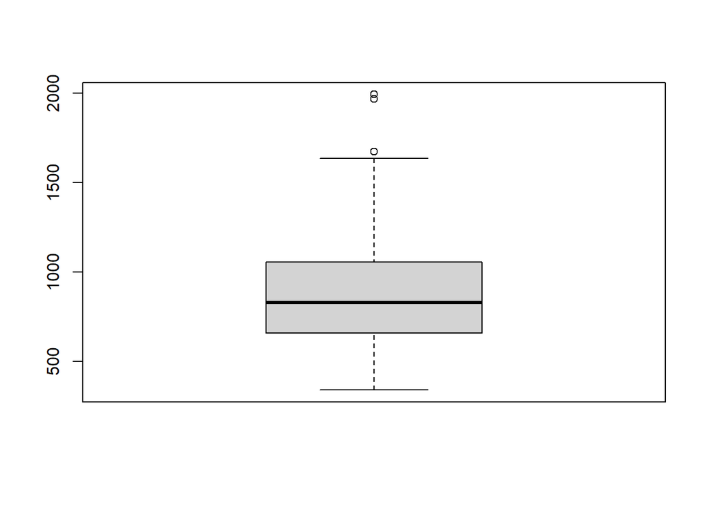

```r
boxplot(UScrime$Crime)
```

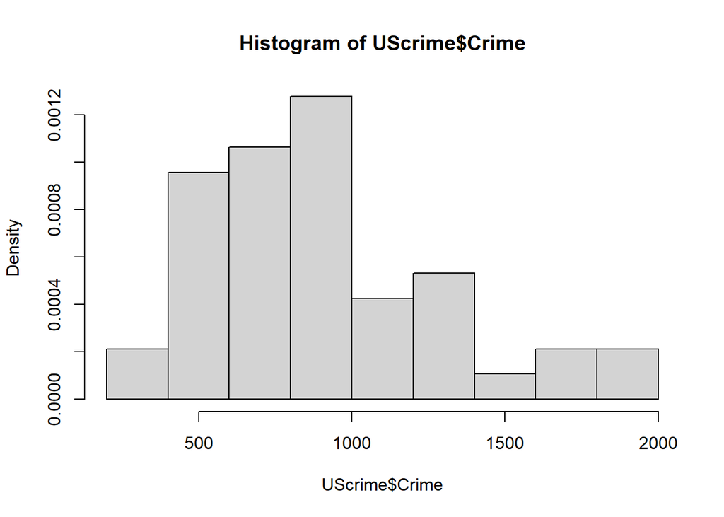

```r
hist(UScrime$Crime, freq=FALSE)
```

From the boxplot and the histogram we can see that the variable `Crime` is unimodal and it is also mindly right skwed.

##### 2. **Fit the linear regression model of `Crime` on all the remaining 15 variables and then remove the variable with largest variance inflation factor, if greater than 10. Repeat this operation iteratively until no variable has variance inflation factor greater than 10.**

```r
library(car)
lm.crime <- lm(Crime~., data=UScrime)
vif(lm.crime)
```

```
##          M         So         Ed        Po1        Po2         LF        M.F
##   2.892448   5.342783   5.077447 104.658667 113.559262   3.712690   3.785934
##        Pop         NW         U1         U2     Wealth       Ineq       Prob
##   2.536708   4.674088   6.063931   5.088880  10.530375   8.644528   2.809459
##       Time
##   2.713785
```

```r
lm.crime <- update(lm.crime, ~.-Po2)
vif(lm.crime)
```

```
##         M        So        Ed       Po1        LF       M.F       Pop        NW
##  2.884547  5.317813  4.893078  5.341037  3.421040  3.779003  2.532206  4.277326
##        U1        U2    Wealth      Ineq      Prob      Time
##  5.997380  5.086769 10.496921  8.564507  2.605654  2.376902
```

```r
lm.crime <- update(lm.crime, ~.-Wealth)
vif(lm.crime)
```

```
##        M       So       Ed      Po1       LF      M.F      Pop       NW
## 2.811116 5.042098 4.765835 4.452843 3.369251 3.735732 2.511806 4.116256
##       U1       U2     Ineq     Prob     Time
## 5.948264 4.960370 5.437735 2.567579 2.352643
```

##### 3. **Fit the resulting linear regression model and name it lm.full. Suggestion: it may be convenient to create a new data frame that contains only the variables involved in this full model.**

```r
names(UScrime)
```

```
##  [1] "M"      "So"     "Ed"     "Po1"    "Po2"    "LF"     "M.F"    "Pop"
##  [9] "NW"     "U1"     "U2"     "Wealth" "Ineq"   "Prob"   "Time"   "Crime"
```

We note that the variable we have removed are in the columns 5 and 12 of the UScrime data.frame

```r
UScrime.new <- UScrime[, -c(5, 12)]
lm.full <- lm(Crime~., data=UScrime.new)
summary(lm.full)
```

```
##
## Call:
## lm(formula = Crime ~ ., data = UScrime.new)
##
## Residuals:
##    Min     1Q Median     3Q    Max
## -469.4  -93.1   12.6  117.3  506.4
##
## Coefficients:
##               Estimate Std. Error t value Pr(>|t|)
## (Intercept) -6041.0176  1515.7345  -3.986 0.000351 ***
## M              84.0350    40.8957   2.055 0.047879 *
## So             35.2894   143.7092   0.246 0.807543
## Ed            185.9198    59.8202   3.108 0.003861 **
## Po1           105.0940    21.7659   4.828 3.06e-05 ***
## LF           -127.9865  1392.3561  -0.092 0.927317
## M.F            20.1254    20.1066   1.001 0.324141
## Pop            -0.6822     1.2761  -0.535 0.596494
## NW              1.3912     6.0482   0.230 0.819502
## U1          -5748.4126  4146.8729  -1.386 0.174980
## U2            180.7362    80.8400   2.236 0.032251 *
## Ineq           60.7323    17.9172   3.390 0.001829 **
## Prob        -4517.0792  2160.3360  -2.091 0.044315 *
## Time           -0.5337     6.6346  -0.080 0.936366
## ---
## Signif. codes:  0 '***' 0.001 '**' 0.01 '*' 0.05 '.' 0.1 ' ' 1
##
## Residual standard error: 207.9 on 33 degrees of freedom
## Multiple R-squared:  0.7927, Adjusted R-squared:  0.711
## F-statistic: 9.707 on 13 and 33 DF,  p-value: 7.32e-08
```

##### 4. **Start from the models lm.full and apply a stepwise backward elimination variable selection where at every step you remove a variable on the basis of the p-values of the coefficients. Use 5% as a threshold. Name the resulting model `lm.reduced`**

```r
summary(lm.full)
```

```
##
## Call:
## lm(formula = Crime ~ ., data = UScrime.new)
##
## Residuals:
##    Min     1Q Median     3Q    Max
## -469.4  -93.1   12.6  117.3  506.4
##
## Coefficients:
##               Estimate Std. Error t value Pr(>|t|)
## (Intercept) -6041.0176  1515.7345  -3.986 0.000351 ***
## M              84.0350    40.8957   2.055 0.047879 *
## So             35.2894   143.7092   0.246 0.807543
## Ed            185.9198    59.8202   3.108 0.003861 **
## Po1           105.0940    21.7659   4.828 3.06e-05 ***
## LF           -127.9865  1392.3561  -0.092 0.927317
## M.F            20.1254    20.1066   1.001 0.324141
## Pop            -0.6822     1.2761  -0.535 0.596494
## NW              1.3912     6.0482   0.230 0.819502
## U1          -5748.4126  4146.8729  -1.386 0.174980
## U2            180.7362    80.8400   2.236 0.032251 *
## Ineq           60.7323    17.9172   3.390 0.001829 **
## Prob        -4517.0792  2160.3360  -2.091 0.044315 *
## Time           -0.5337     6.6346  -0.080 0.936366
## ---
## Signif. codes:  0 '***' 0.001 '**' 0.01 '*' 0.05 '.' 0.1 ' ' 1
##
## Residual standard error: 207.9 on 33 degrees of freedom
## Multiple R-squared:  0.7927, Adjusted R-squared:  0.711
## F-statistic: 9.707 on 13 and 33 DF,  p-value: 7.32e-08
```

```r
# 1
lm.reduced <- update(lm.full, ~.-Time)
summary(lm.reduced)
```

```
##
## Call:
## lm(formula = Crime ~ M + So + Ed + Po1 + LF + M.F + Pop + NW +
##     U1 + U2 + Ineq + Prob, data = UScrime.new)
##
## Residuals:
##     Min      1Q  Median      3Q     Max
## -465.78  -92.59   14.53  113.42  503.09
##
## Coefficients:
##               Estimate Std. Error t value Pr(>|t|)
## (Intercept) -6083.1051  1401.6504  -4.340 0.000121 ***
## M              83.4566    39.6663   2.104 0.042853 *
## So             36.3880   140.9533   0.258 0.797843
## Ed            186.3828    58.6663   3.177 0.003161 **
## Po1           105.3926    21.1314   4.987 1.78e-05 ***
## LF           -132.1927  1370.8945  -0.096 0.923747
## M.F            20.3860    19.5518   1.043 0.304459
## Pop            -0.7081     1.2167  -0.582 0.564404
## NW              1.2936     5.8382   0.222 0.825970
## U1          -5709.7273  4058.2723  -1.407 0.168522
## U2            179.8418    78.8933   2.280 0.029029 *
## Ineq           60.8199    17.6208   3.452 0.001508 **
## Prob        -4423.1791  1791.1294  -2.469 0.018710 *
## ---
## Signif. codes:  0 '***' 0.001 '**' 0.01 '*' 0.05 '.' 0.1 ' ' 1
##
## Residual standard error: 204.8 on 34 degrees of freedom
## Multiple R-squared:  0.7927, Adjusted R-squared:  0.7195
## F-statistic: 10.83 on 12 and 34 DF,  p-value: 2.147e-08
```

```r
# 2
lm.reduced <- update(lm.reduced, ~.-LF)
summary(lm.reduced)
```

```
##
## Call:
## lm(formula = Crime ~ M + So + Ed + Po1 + M.F + Pop + NW + U1 +
##     U2 + Ineq + Prob, data = UScrime.new)
##
## Residuals:
##     Min      1Q  Median      3Q     Max
## -464.75  -92.64   11.51  112.02  504.10
##
## Coefficients:
##               Estimate Std. Error t value Pr(>|t|)
## (Intercept) -6056.5920  1354.8267  -4.470 7.85e-05 ***
## M              84.0638    38.6051   2.178  0.03627 *
## So             42.7391   122.8423   0.348  0.72999
## Ed            184.6252    54.9681   3.359  0.00190 **
## Po1           105.9077    20.1538   5.255 7.41e-06 ***
## M.F            19.3310    15.9730   1.210  0.23430
## Pop            -0.7276     1.1827  -0.615  0.54241
## NW              1.1383     5.5318   0.206  0.83815
## U1          -5533.9991  3574.4007  -1.548  0.13056
## U2            179.1942    77.4864   2.313  0.02675 *
## Ineq           60.5006    17.0602   3.546  0.00113 **
## Prob        -4412.0201  1761.9089  -2.504  0.01709 *
## ---
## Signif. codes:  0 '***' 0.001 '**' 0.01 '*' 0.05 '.' 0.1 ' ' 1
##
## Residual standard error: 201.9 on 35 degrees of freedom
## Multiple R-squared:  0.7926, Adjusted R-squared:  0.7274
## F-statistic: 12.16 on 11 and 35 DF,  p-value: 5.946e-09
```

```r
# 3
lm.reduced <- update(lm.reduced, ~.-NW)
summary(lm.reduced)
```

```
##
## Call:
## lm(formula = Crime ~ M + So + Ed + Po1 + M.F + Pop + U1 + U2 +
##     Ineq + Prob, data = UScrime.new)
##
## Residuals:
##     Min      1Q  Median      3Q     Max
## -467.87  -91.30   13.98  109.19  509.68
##
## Coefficients:
##               Estimate Std. Error t value Pr(>|t|)
## (Intercept) -6062.2682  1336.4079  -4.536 6.14e-05 ***
## M              86.8431    35.6812   2.434 0.020030 *
## So             50.3385   115.5912   0.435 0.665809
## Ed            183.5806    54.0003   3.400 0.001664 **
## Po1           107.3449    18.6517   5.755 1.48e-06 ***
## M.F            18.8102    15.5601   1.209 0.234590
## Pop            -0.7137     1.1650  -0.613 0.543986
## U1          -5492.2299  3520.8475  -1.560 0.127528
## U2            178.9654    76.4410   2.341 0.024875 *
## Ineq           61.4758    16.1694   3.802 0.000535 ***
## Prob        -4338.4728  1702.1762  -2.549 0.015218 *
## ---
## Signif. codes:  0 '***' 0.001 '**' 0.01 '*' 0.05 '.' 0.1 ' ' 1
##
## Residual standard error: 199.2 on 36 degrees of freedom
## Multiple R-squared:  0.7923, Adjusted R-squared:  0.7347
## F-statistic: 13.74 on 10 and 36 DF,  p-value: 1.571e-09
```

```r
# 4
lm.reduced <- update(lm.reduced, ~.-So)
summary(lm.reduced)
```

```
##
## Call:
## lm(formula = Crime ~ M + Ed + Po1 + M.F + Pop + U1 + U2 + Ineq +
##     Prob, data = UScrime.new)
##
## Residuals:
##     Min      1Q  Median      3Q     Max
## -470.97 -104.20    8.31  117.37  502.63
##
## Coefficients:
##               Estimate Std. Error t value Pr(>|t|)
## (Intercept) -6068.1757  1321.6242  -4.591 4.95e-05 ***
## M              91.1349    33.9155   2.687  0.01073 *
## Ed            181.4908    53.1944   3.412  0.00158 **
## Po1           108.7265    18.1775   5.981 6.65e-07 ***
## M.F            17.9369    15.2604   1.175  0.24735
## Pop            -0.7533     1.1486  -0.656  0.51600
## U1          -5855.3447  3383.0241  -1.731  0.09182 .
## U2            187.5617    73.0352   2.568  0.01440 *
## Ineq           64.2130    14.7338   4.358  0.00010 ***
## Prob        -4050.5933  1551.2988  -2.611  0.01296 *
## ---
## Signif. codes:  0 '***' 0.001 '**' 0.01 '*' 0.05 '.' 0.1 ' ' 1
##
## Residual standard error: 197 on 37 degrees of freedom
## Multiple R-squared:  0.7913, Adjusted R-squared:  0.7405
## F-statistic: 15.58 on 9 and 37 DF,  p-value: 4.169e-10
```

```r
# 5
lm.reduced <- update(lm.reduced, ~.-Pop)
summary(lm.reduced)
```

```
##
## Call:
## lm(formula = Crime ~ M + Ed + Po1 + M.F + U1 + U2 + Ineq + Prob,
##     data = UScrime.new)
##
## Residuals:
##     Min      1Q  Median      3Q     Max
## -444.70 -111.07    3.03  122.15  483.30
##
## Coefficients:
##             Estimate Std. Error t value Pr(>|t|)
## (Intercept) -6426.10    1194.61  -5.379 4.04e-06 ***
## M              93.32      33.50   2.786  0.00828 **
## Ed            180.12      52.75   3.414  0.00153 **
## Po1           102.65      15.52   6.613 8.26e-08 ***
## M.F            22.34      13.60   1.642  0.10874
## U1          -6086.63    3339.27  -1.823  0.07622 .
## U2            187.35      72.48   2.585  0.01371 *
## Ineq           61.33      13.96   4.394 8.63e-05 ***
## Prob        -3796.03    1490.65  -2.547  0.01505 *
## ---
## Signif. codes:  0 '***' 0.001 '**' 0.01 '*' 0.05 '.' 0.1 ' ' 1
##
## Residual standard error: 195.5 on 38 degrees of freedom
## Multiple R-squared:  0.7888, Adjusted R-squared:  0.7444
## F-statistic: 17.74 on 8 and 38 DF,  p-value: 1.159e-10
```

```r
# 6
lm.reduced <- update(lm.reduced, ~.-M.F)
summary(lm.reduced)
```

```
##
## Call:
## lm(formula = Crime ~ M + Ed + Po1 + U1 + U2 + Ineq + Prob, data = UScrime.new)
##
## Residuals:
##     Min      1Q  Median      3Q     Max
## -520.76 -105.67    9.53  136.28  519.37
##
## Coefficients:
##             Estimate Std. Error t value Pr(>|t|)
## (Intercept) -5095.55     896.90  -5.681 1.43e-06 ***
## M             106.78      33.18   3.218   0.0026 **
## Ed            218.45      48.33   4.520 5.62e-05 ***
## Po1           105.96      15.72   6.738 4.91e-08 ***
## U1          -3542.35    3021.94  -1.172   0.2482
## U2            158.82      71.89   2.209   0.0331 *
## Ineq           66.33      13.92   4.767 2.61e-05 ***
## Prob        -3730.85    1522.21  -2.451   0.0188 *
## ---
## Signif. codes:  0 '***' 0.001 '**' 0.01 '*' 0.05 '.' 0.1 ' ' 1
##
## Residual standard error: 199.8 on 39 degrees of freedom
## Multiple R-squared:  0.7738, Adjusted R-squared:  0.7332
## F-statistic: 19.06 on 7 and 39 DF,  p-value: 8.805e-11
```

```r
# 7
lm.reduced <- update(lm.reduced, ~.-U1)
summary(lm.reduced)
```

```
##
## Call:
## lm(formula = Crime ~ M + Ed + Po1 + U2 + Ineq + Prob, data = UScrime.new)
##
## Residuals:
##     Min      1Q  Median      3Q     Max
## -470.68  -78.41  -19.68  133.12  556.23
##
## Coefficients:
##             Estimate Std. Error t value Pr(>|t|)
## (Intercept) -5040.50     899.84  -5.602 1.72e-06 ***
## M             105.02      33.30   3.154  0.00305 **
## Ed            196.47      44.75   4.390 8.07e-05 ***
## Po1           115.02      13.75   8.363 2.56e-10 ***
## U2             89.37      40.91   2.185  0.03483 *
## Ineq           67.65      13.94   4.855 1.88e-05 ***
## Prob        -3801.84    1528.10  -2.488  0.01711 *
## ---
## Signif. codes:  0 '***' 0.001 '**' 0.01 '*' 0.05 '.' 0.1 ' ' 1
##
## Residual standard error: 200.7 on 40 degrees of freedom
## Multiple R-squared:  0.7659, Adjusted R-squared:  0.7307
## F-statistic: 21.81 on 6 and 40 DF,  p-value: 3.418e-11
```

```r
lm.reduced <- lm(Crime ~ M + Ed + Po1 + U2 + Ineq + Prob, data = UScrime)
summary(lm.reduced)
```

```
##
## Call:
## lm(formula = Crime ~ M + Ed + Po1 + U2 + Ineq + Prob, data = UScrime)
##
## Residuals:
##     Min      1Q  Median      3Q     Max
## -470.68  -78.41  -19.68  133.12  556.23
##
## Coefficients:
##             Estimate Std. Error t value Pr(>|t|)
## (Intercept) -5040.50     899.84  -5.602 1.72e-06 ***
## M             105.02      33.30   3.154  0.00305 **
## Ed            196.47      44.75   4.390 8.07e-05 ***
## Po1           115.02      13.75   8.363 2.56e-10 ***
## U2             89.37      40.91   2.185  0.03483 *
## Ineq           67.65      13.94   4.855 1.88e-05 ***
## Prob        -3801.84    1528.10  -2.488  0.01711 *
## ---
## Signif. codes:  0 '***' 0.001 '**' 0.01 '*' 0.05 '.' 0.1 ' ' 1
##
## Residual standard error: 200.7 on 40 degrees of freedom
## Multiple R-squared:  0.7659, Adjusted R-squared:  0.7307
## F-statistic: 21.81 on 6 and 40 DF,  p-value: 3.418e-11
```

##### 5. **Use an F-test to compare the full and the reduced model. State the hypothesis verified by this test discuss the results. Use the RSS values and the degrees of freedom provide by the ANOVA table to compute explicitly the value of the F-statistic and the associated p-value.**

This test verifies the null hypothesis that the coefficients of the variables not included in the reduced model are all jointly equal to zero, against the alternative hypothesis that at least one is not zero. According to the p-value, that is equal to 0.74, we cannot reject the null hypothesis.

```r
anova(lm.reduced, lm.full)
```

```
## Analysis of Variance Table
##
## Model 1: Crime ~ M + Ed + Po1 + U2 + Ineq + Prob
## Model 2: Crime ~ M + So + Ed + Po1 + LF + M.F + Pop + NW + U1 + U2 + Ineq +
##     Prob + Time
##   Res.Df     RSS Df Sum of Sq      F Pr(>F)
## 1     40 1611057
## 2     33 1426447  7    184609 0.6101 0.7433
```

The observed value of the F-statistic and the p-value can be computed as follows,

```r
F.obs <- ((1611057-1426447)/7)/(1426447/33)
F.obs
```

```
## [1] 0.6101203
```

```r
p.value <- 1 - pf(F.obs, 7, 33)
p.value
```

```
## [1] 0.7433448
```

##### 6. **Carry a diagnostic check of the reduced model based on the following 4 plots: a) residuals vs fitted, b) residuals qqplot c) scale-location and d) residuals vs leverage. Provide some comments (it is not required to modify the selected model accordingly).**

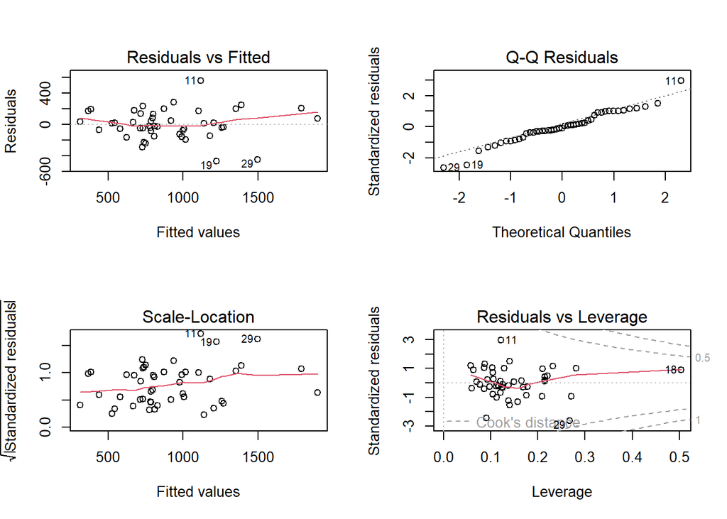

```r
par(mfrow=c(2,2))
plot(lm.reduced)
```

```r
par(mfrow=c(1,1))
```

```r
n <- dim(UScrime)[1]
p.plus.1 <- length(coef(lm.reduced))
3*p.plus.1/n
```

```
## [1] 0.4468085
```

the observation number 18 has high-leverage effect.

##### 7. **Apply the Best Subset Selection method to identify the best models according to Mallows’ Cp (i.e. AIC), BIC and adjusted-r.squared. Compare the three selected models with the model previously obtained by the backward elimination method. Only include in the search all (and only) the variables of the above full model.**

```r
library(leaps)
regfit.full <- regsubsets(Crime ~ ., data = UScrime.new,  nvmax = 13)
bss.summary <- summary(regfit.full)
```

The best model according to Mallows’ Cp is

```r
idx <- which.min(bss.summary$cp)
idx
```

```
## [1] 6
```

```r
coef(regfit.full, idx)
```

```
## (Intercept)           M          Ed         Po1          U2        Ineq
## -5040.50498   105.01957   196.47120   115.02419    89.36604    67.65322
##        Prob
## -3801.83628
```

The best model according to BIC is,

```r
idx <- which.min(bss.summary$bic)
idx
```

```
## [1] 6
```

```r
coef(regfit.full, idx)
```

```
## (Intercept)           M          Ed         Po1          U2        Ineq
## -5040.50498   105.01957   196.47120   115.02419    89.36604    67.65322
##        Prob
## -3801.83628
```

The best model according to the adjusted-r.squared is,

```r
idx <- which.max(bss.summary$adjr2)
idx
```

```
## [1] 8
```

```r
coef(regfit.full, idx)
```

```
## (Intercept)           M          Ed         Po1         M.F          U1
## -6426.10102    93.32155   180.12011   102.65316    22.33975 -6086.63315
##          U2        Ineq        Prob
##   187.34512    61.33494 -3796.03183
```

We can finally take a look at the variables selected by the backward elimination methods,

```r
coef(lm.reduced)
```

```
## (Intercept)           M          Ed         Po1          U2        Ineq
## -5040.50498   105.01957   196.47120   115.02419    89.36604    67.65322
##        Prob
## -3801.83628
```

We can see that Mallows’ Cp and BIC select the same model, with 6 predictors, and that this model coincides with that selected by backward elimination. On the other hand, the adjusted r.squared statistics leads to the selection of a model with 8 predictor, that differs from the previous models for the presence of the two additional variables `M.F` and `U1`.

##### 8. **Apply the Best Subset Selection method to identify the best models according the Leave One Out Cross Validation, plot the cross validated mean square errors and discuss the result. You can use the `make.formula()` function, give below.**

```r
# response    = character string with the name of the response
# var.names   = character vector with all the variable names
# out.summary = output of summary() when applied to a "regsubset" object
# idx         = index of the required model
# resp.trans  = required transformation of the response

make.formula <- function(response, var.names, out.summary, idx, resp.trans =NULL){
  is.in.selected <- out.summary$which[idx,]
  pred.names     <- var.names[var.names!=response]
  predictors     <- pred.names[is.in.selected[-1]]
  model.f        <- paste(predictors, collapse="+")
  if(!is.null(resp.trans)) response <- resp.trans
  model.f        <- paste(response, "~", model.f)
  return(model.f)
}
```

```r
library(boot)
```

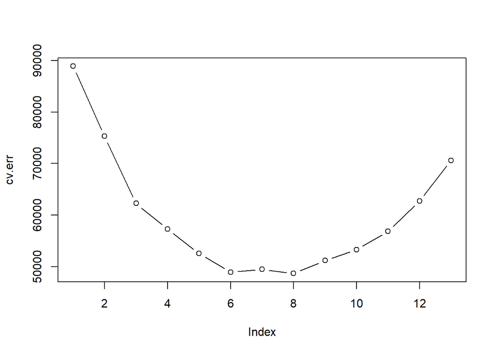

```r
n <- dim(UScrime.new)[1]

cv.err <- rep(0, length=13)
for(i in 1:13){
  mod.formula <- make.formula("Crime", names(UScrime.new), bss.summary, i)
  lm.fit <- glm(mod.formula, data=UScrime.new)
  cv.err[i] <- cv.glm(UScrime.new, lm.fit, K=n)$delta[[1]]
}

plot(cv.err, type="b")
```

```r
which.min(cv.err)
```

```
## [1] 8
```

LOOCV agrees with the result provided by adjusted R.squared, and leads to the selection of the model with 8 predictors, however the plot of the cross validated mean squared errors seems to suggest that the models with 6, 7 and 8 predictors perform equivalently well.